# 1 Основные сведения об R

## 1.1 Что такое R?

R – это язык программирования и свободная программная среда для статистической обработки и визуализации данных.

Несмотря на наличие огромного количества языков и различных программ для статистической обработки данных, R в течение двух десятилетий остается популярным языком и средой обработки и анализа данных для специалистов из разных областей знания.

[figure not shown]

Прежде всего, это язык, который используют ученые, специалисты, работающие в различных отраслях экономики, менеджеры для анализа реальных данных и разработки научно обоснованных систем принятия решений, поэтому место в общем рейтинге не так высоко. Если посмотреть сферы использования, то на первом месте - академическая среда, на втором - сфера здравоохранения, на третьем - правительственные учреждения.

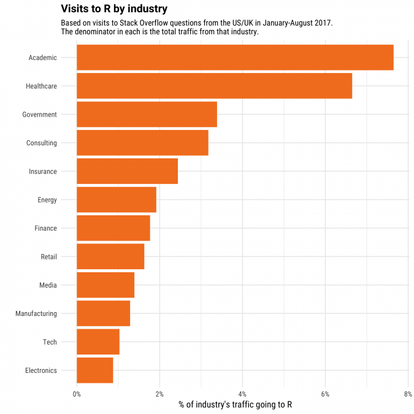

R используют банки и маркетинговые агентства, технические компании и информационные корпорации для разных целей - от обработки данных до прогнозирования и представления интерактивной инфографики.

Вот только небольшой список тех компаний, которые используют R в своей деятельности.

[figure not shown]

## 1.2 Немного истории

R был создан профессорами **Россом Айхэка** и **Робертом Джентельменом** (Ross Ihaka и Robert Gentleman) в 1992 году, сначала как язык программирования для обучения студентов статистике в университете Окленда (Новая Зеландия). Авторы вдохновлялись при создании языком S, используемым в лаборатории Bell, и ради шутки назвали язык R - по первым буквам собственных имен.

В июне 1995 года статистик **Мартин Махлер** убедил Айхэку и Джентельмена опубликовать R как язык со свободным исходным кодом под публичной лицензией GNU. Первая официальная версия была выпущена 29 февраля 2000 года.

Чуть ранее, в 1997 году **Куртом Хорником** и **Фрицем Лейшем** была основана Сеть для архивирования кода R (CRAN, The Comprehensive R Archive Network), цель которой заключалась в хранении исходного кода, выполняемых файлов, документации и библиотек, создаваемых пользователями. На момент декабря 2022 года CRAN имел 103 зеркальных сервера и 18 976 библиотек.

Команда разработчиков (R Core Team) также была основана в 1997 году для дальнейшего развития языка. Сейчас в ней состоят ведующие разработчики, статистики, специалисты по компьютерным наукам, всего более 20 человек. В апреле 2003 года для развития проекта была создана некоммерческая организация R Foundation. Цель фонда заключается в предоставлении технической поддержки и коммуникации с создателями R, хранении и управлении технической документацией и интеллектуальной собственностью.

Подробнее об истории создания R можно узнать из таймлайна:

[figure not shown]

Создатели R (Питер Далгаард - датский ученый, один из членов R Core Team):

[figure not shown]

## 1.3 Каковы преимущества R?

Их довольно много:

1. Возможности для **статистической обработки**, от простых функций до сложных моделей.

Почти все новое, что появляется в области статистики, можно найти в одной из библиотек R. Например, ANZ банк использует R для моделирования невыплат по ипотечному кредитованию, а The Bank Of America применяет R для формирования финансовой отчетности.

2. Это язык программирования **с открытым исходным кодом** (Open-source)

Что это значит? Это значит, что, во-первых, все написанное на R открыто для изучения и критики, а, во-вторых, каждый может внести вклад в его развитие и улучшение путем создания новых библиотек и новых функций для решения различных задач.

3. **Поддержка сообщества** (Community)

У R - более 2 миллионов пользователей по всему миру, сообщество пользователей R не только внушительное по размеру, но и очень активное. Каким бы ни был ваш проект - учебным или крупномасштабным, всегда найдется тот, кто поможет разобраться в коде и принять правильное решение. Вы тоже можете найти себе единомышленников и подключаться к другим проектам.

Некоторые полезные ссылки:

- https://community.rstudio.com/
- https://www.r-bloggers.com/
- https://stackoverflow.com/questions/tagged/r
- https://rweekly.org/ https://www.reddit.com/r/Rlanguage/
- https://r.awesome-programming.com/en/awesome/r-language-02/community

Коммьюнити пользователей R это совсем не Man’s World: весьма активно женское сообщество [RLadies](https://en.wikipedia.org/wiki/R-Ladies), устраивающее митапы по всему миру и продвигающее свой особый, женский, взгляд на использование R для разработки и анализа данных.

4. Огромная **коллекция библиотек и полезных функций**, позволяющих расширить возможности базового языка

Самые авторитетные хранятся в CRAN (Comprehensive R Archive Network), их более 10 тысяч, однако, чтобы попасть туда, необходимо, чтобы документация и код соответствовали определенным требованиям, что требует времени. До того момента, когда библиотека загружена на CRAN, она, как правило, хранится в открытом доступе, например, на [github](https://github.com/search?q=R), где каждый желающий может принять участие в ее тестировании и доработке.

Пример сетевого анализа библиотек и их взаимозависимостей представлен на рисунке ниже:

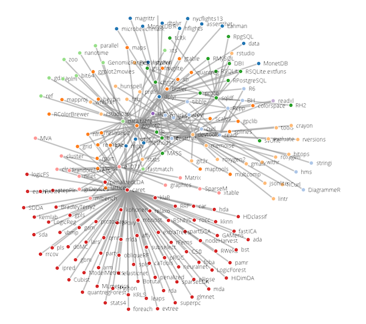

Примеры полезных библиотек:

- обработка и всевозможные манипуляции с данными (`tidytverse`)
- работа с большими данными (`sparklyr`)
- глубокое обучение (`keras`, `TensorFlow`)
- машинное обучение (`H2O`)
- визуализация данных (`ggplot2`)
- создание отчетов, итерактивная графика и обучение (`Rmarkdown`, `shiny`).
5. **Совместимость с другими языками программирования**

Большинство функций и библиотек написаны на самом языке R. Однако, для сложных вычислительных задач, могут использоваться и другие языки, такие как C, C++, FORTRAN. Для манипуляций с объектами, возможно использование других языков - .NET, Java, Python. Иными словами, возможности программирования становятся практически безграничными.

6. Создание привлекательных **визуализаций**

В современном мире анализ данных невозможен без качественной визуализации, особенно если его результаты планируется использовать в сфере политики и бизнеса. R является одним из лучших инструментов для создания качественной графики, и такие библиотеки как `ggplot2`, `plotly`, `ggvis` помогут создать очень детализированные и эстетически привлекательные визуализации.

Для пользователей R, которые только начинают изучение языка, на сайте https://r-graph-gallery.com создана галерея визуализаций, разбитых по отдельным тематикам. На основе простых и более сложных примеров можно изучить код и адаптировать его под собственные задачи.

[interactive chart not shown]

7. **Интеграция с Hadoop и анализ больших данных**

Если перед вами стоит задача анализа больших данных, то с такими библиотеками как `rmr`, `rhdfs`, `rhbase`, `RHIVE`, `RHIPE` и `Rhadoop` возможно интегрировать R и Hadoop (проект фонда Apache Software Foundation для разработки и выполнения распределённых вычислений для работы с большими данными).

Возможности по хранению данных Hadoop и вычислительные достоинства R используют многие в качестве оптимального решения для анализа больших данных. Например, компания Форд использует R и Hadoop для обработки данных обратной связи с потребителями, что позволяет им улучшить дизайн и обосновывать бизнес решения.

[figure not shown]

8. Создание **интерактивных веб-приложений**

С помощью R и библиотеки `shiny` можно создавать интерактивные приложения, с помощью которых пользователи (ученики, заказчики, журналисты и пр.) могут познакомиться с вашими данными, провести какие-то виды анализа, сделать визуализацию, возможно изучить какие-то закономерности (часто используются как обучающий инструмент). Эти приложения можно хранить на сервере Shiny или в другом доступном месте.

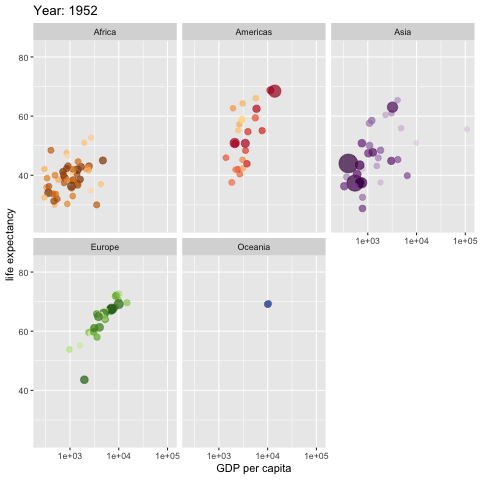

Примеры можно посмотреть в галерее на сайте `shiny`: (https://shiny.posit.co/r/gallery/):

[interactive chart not shown]

9. **Совместимость с другими платформами**

R может работать с любой конфигурацией оборудования и поддерживает различные операционные системы, независимо от окружения выдает предсказуемые и однозначные результаты.

10. Возможность запуска кода **без компилирования** (возможно этот пункт стоило бы поставить на одно из первых мест)

R относится к *интерпретируемым* языкам, что означает, что ему не требуется компилятор для того, чтобы программа заработала. Иными словами, все команды, которые мы вводим, сразу же выполняются, без дополнительного компилирования (сборки), как это происходит в других языках, например в C, COBOL, Delphi или Fortran. Другими возможностями, которыми обладают интерпретируемые языки, являются кросс-платформенность (способность работать в разных операционных системах и аппаратных средах), простота тестирования и отладки программ.

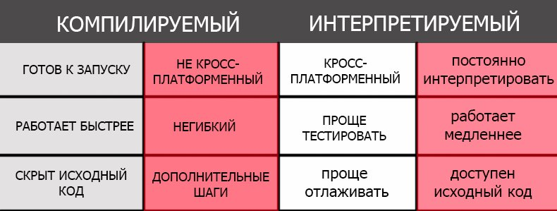

Например, Если мы создадим несколько строк кода и запустим их, они выполнятся немедленно и мы увидим результат:

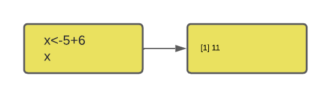

Кроме этих преимуществ есть и много других, о которых мы узнаем в процессе изучения курса.

К слову сказать, данное пособие также создано с помощью R. При его создании использовались возможности open-source системы публикации научной и технической информациии **Quarto**.

# 2 Кое-что еще о разработчиках R

Кроме основной команды, в сообществе R выделяются талантливые программисты, которые разрабатывают библиотеки, без преувеличения производящие революцию в обработке и анализе данных. Это настоящие гуру, которых очень уважают в исследовательском сообществе, их имена знают все, кто работает в R. Ну, или почти все…

ТОП-3 по личному и очень субъективному мнению автора, которое основывается на его собственном опыте и может не совпадать с другими оценками, включает следующих разработчиков:

1. **Хэдли Уикхэм** (Hadley Wickham) - программист из Новой Зеландии, главный научный сотрудник в компании Posit (создана в 2022 году в продолжение и развитие компании RStudio). Без преувеличения самый известнй, очень трудолюбивый и плодотворный разработчик R, автор более 100 (!) библиотек, в том числе таких мегапопулярных как `ggplot`, `dplyr`, `tidyverse`, `devtools` и других. Этими библиотеками воспользовались более 825 тыс. человек.

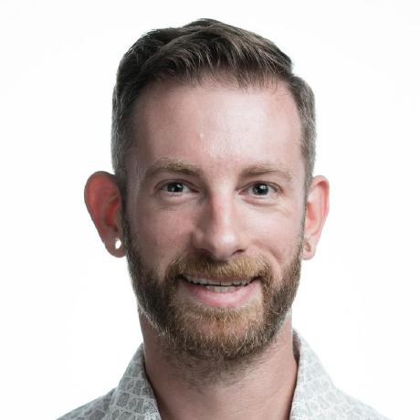

2. **Дирк Эддельбуэттель** (Dirk Eddelbuettel) - канадский ученый в области статистики, программист и исследователь, второй в нашем списке лучших разработчиков библиотек для R. Принял участие в создании более 60 библиотек, наиболее популярными среди которых является `Rcpp`, позволяющая интегрировать R с другим не менее популярным языком C++, а также `RPostgreSQL`, предоставляющая интерфейс для работы с системой баз данных PostgreSQL. Работает в Иллинойском университете в Урбане-Шампейне.

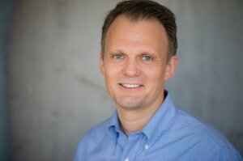

3. **Ихуэй Се** (Yihui Xie) - еще один плодовитый разрботчик, создавший более 40 библиотек, загруженных более 130 тыс. раз. Его большая заслуга в том, что разработал инструменты для создания интерактивных приложений (`knitr`, `rmarkdown`, `shiny` и `htmlwidgets` - его детища, и мы тоже с ними познакомимся на следующих занятиях). Yihui Xie также поддерживает систему `bookdown`, которую можно использовать для написания книг и отчетных документов с помощью R Markdown. Инженер-программист компании RStudio.

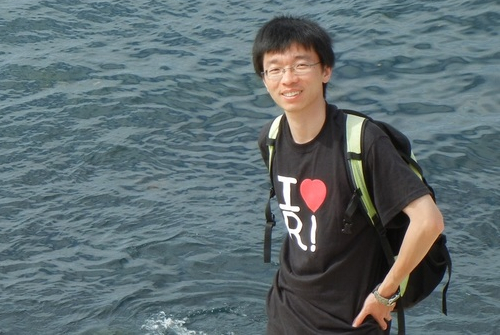

# 3 Вопросы для самопроверки

**1. Каким языком является R?**

компилируемым процедурным интерпретируемым структурным

**2. Может ли R быть интегрирована с Hadoop для обработки больших данных?**

**3. На основе какого языка создан R?**

Python Oracle S Java